# Lab 12 Homework

Joyce Lin

2025-02-25

## Instructions

Answer the following questions and complete the exercises in RMarkdown. Please embed all of your code and push your final work to your repository. Your final lab report should be organized, clean, and run free from errors. Remember, you must remove the `#` for the included code chunks to run. Be sure to add your name to the author header above. For any included plots, make sure they are clearly labeled. You are free to use any plot type that you feel best communicates the results of your analysis.

Make sure to use the formatting conventions of RMarkdown to make your report neat and clean!

## Load the libraries

```r
library(tidyverse)
library(janitor)
library(naniar)
library(gtools)
```

```r
options(scipen = 999)
```

```r
#install.packages("gtools")
```

## Resources

The idea for this assignment came from [Rebecca Barter’s](http://www.rebeccabarter.com/blog/2017-11-17-ggplot2_tutorial/) ggplot tutorial so if you get stuck this is a good place to have a look.

## Gapminder

For this assignment, we are going to use the dataset [gapminder](https://cran.r-project.org/web/packages/gapminder/index.html). Gapminder includes information about economics, population, and life expectancy from countries all over the world. You will need to install it before use.

```r
#install.packages("gapminder")
library("gapminder")
gapminder
```

```
## # A tibble: 1,704 × 6
##    country     continent  year lifeExp      pop gdpPercap
##    <fct>       <fct>     <int>   <dbl>    <int>     <dbl>
##  1 Afghanistan Asia       1952    28.8  8425333      779.
##  2 Afghanistan Asia       1957    30.3  9240934      821.
##  3 Afghanistan Asia       1962    32.0 10267083      853.
##  4 Afghanistan Asia       1967    34.0 11537966      836.
##  5 Afghanistan Asia       1972    36.1 13079460      740.
##  6 Afghanistan Asia       1977    38.4 14880372      786.
##  7 Afghanistan Asia       1982    39.9 12881816      978.
##  8 Afghanistan Asia       1987    40.8 13867957      852.
##  9 Afghanistan Asia       1992    41.7 16317921      649.
## 10 Afghanistan Asia       1997    41.8 22227415      635.
## # ℹ 1,694 more rows
```

1. Use the function(s) of your choice to get an idea of the overall structure of the data frame, including its dimensions, column names, variable classes, etc. As part of this, determine how NA’s are treated in the data.

*It is a long structure, and it has no NAs in the data*

```r
summary(gapminder)
```

```
##         country        continent        year         lifeExp
##  Afghanistan:  12   Africa  :624   Min.   :1952   Min.   :23.60
##  Albania    :  12   Americas:300   1st Qu.:1966   1st Qu.:48.20
##  Algeria    :  12   Asia    :396   Median :1980   Median :60.71
##  Angola     :  12   Europe  :360   Mean   :1980   Mean   :59.47
##  Argentina  :  12   Oceania : 24   3rd Qu.:1993   3rd Qu.:70.85
##  Australia  :  12                  Max.   :2007   Max.   :82.60
##  (Other)    :1632
##       pop               gdpPercap
##  Min.   :     60011   Min.   :   241.2
##  1st Qu.:   2793664   1st Qu.:  1202.1
##  Median :   7023596   Median :  3531.8
##  Mean   :  29601212   Mean   :  7215.3
##  3rd Qu.:  19585222   3rd Qu.:  9325.5
##  Max.   :1318683096   Max.   :113523.1
##
```

```r
gapminder %>%
  summarize(across(everything(), ~ sum(is.na(.))))
```

```
## # A tibble: 1 × 6
##   country continent  year lifeExp   pop gdpPercap
##     <int>     <int> <int>   <int> <int>     <int>
## 1       0         0     0       0     0         0
```

```r
dim(gapminder)
```

```
## [1] 1704    6
```

```r
names(gapminder)
```

```
## [1] "country"   "continent" "year"      "lifeExp"   "pop"       "gdpPercap"
```

```r
class(gapminder)
```

```
## [1] "tbl_df"     "tbl"        "data.frame"
```

2. How many countries are represented in this dataset? Make a table and a plot that shows the number of countries by continent.

*There are a total of 142 countries, including 52 African countries, 33 Asian countries, 30 European countries, 25 American countries, and 2 Oceanian countries*

```r
gapminder %>%
  summarize(dis_con=n_distinct(country))
```

```
## # A tibble: 1 × 1
##   dis_con
##     <int>
## 1     142
```

```r
gapminder %>%
  group_by(continent) %>%
  summarize(n_con=n_distinct(country)) %>%
  arrange(-n_con)
```

```
## # A tibble: 5 × 2
##   continent n_con
##   <fct>     <int>
## 1 Africa       52
## 2 Asia         33
## 3 Europe       30
## 4 Americas     25
## 5 Oceania       2
```

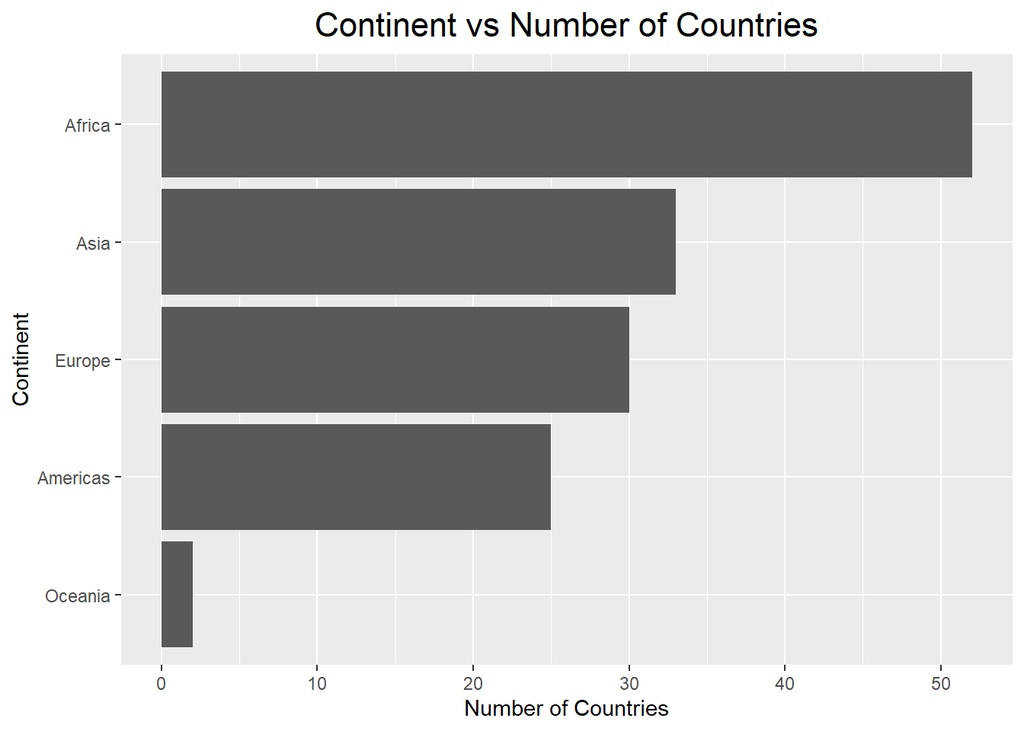

```r
gapminder %>%
  group_by(continent) %>%
  summarize(n_con=n_distinct(country)) %>%
  ggplot(aes(x=reorder(continent, n_con), y=n_con))+
  geom_col()+
  labs(title = "Continent vs Number of Countries",
       x= "Continent",
       y= "Number of Countries")+
  coord_flip()+
  theme(plot.title = element_text(size=rel(1.5), hjust=0.5))
```

3. Which country has the largest population growth since 1952? Show this as a table.

*China has the largest population growth since 1952*

```r
gapminder %>%
  filter(year>=1952) %>%
  group_by(country) %>%
  summarize(min_pop=min(pop), max_pop=max(pop)) %>%
  mutate(pop_growth= max_pop-min_pop) %>%
  arrange(-pop_growth)
```

```
## # A tibble: 142 × 4
##    country         min_pop    max_pop pop_growth
##    <fct>             <int>      <int>      <int>
##  1 China         556263527 1318683096  762419569
##  2 India         372000000 1110396331  738396331
##  3 United States 157553000  301139947  143586947
##  4 Indonesia      82052000  223547000  141495000
##  5 Brazil         56602560  190010647  133408087
##  6 Pakistan       41346560  169270617  127924057
##  7 Bangladesh     46886859  150448339  103561480
##  8 Nigeria        33119096  135031164  101912068
##  9 Mexico         30144317  108700891   78556574
## 10 Philippines    22438691   91077287   68638596
## # ℹ 132 more rows
```

4. Make a plot that shows population growth for the country you found in question #3. This plot should show the change over time.

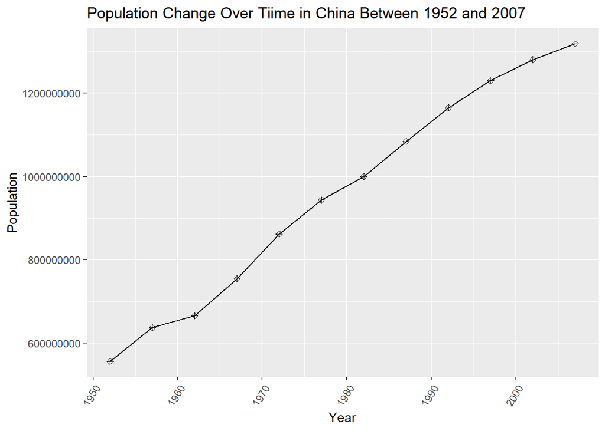

```r
gapminder %>%
  filter(country=="China") %>%
  ggplot(aes(x=year, y=pop))+
  geom_line()+
  geom_point(shape=9)+
  labs(title = "Population Change Over Tiime in China Between 1952 and 2007",
       x= "Year",
       y="Population")+
  theme(axis.text.x = element_text(angle = 60, hjust = 1))
```

5. How has global life expectancy changed between 1952 and 2007? Show the min, mean, and max for all countries in the dataset. Show this as a table.

```r
gapminder %>%
  group_by(country) %>%
  summarize(min_lif=min(lifeExp), max_lif=max(lifeExp), mean_lif=mean(lifeExp))
```

```
## # A tibble: 142 × 4
##    country     min_lif max_lif mean_lif
##    <fct>         <dbl>   <dbl>    <dbl>
##  1 Afghanistan    28.8    43.8     37.5
##  2 Albania        55.2    76.4     68.4
##  3 Algeria        43.1    72.3     59.0
##  4 Angola         30.0    42.7     37.9
##  5 Argentina      62.5    75.3     69.1
##  6 Australia      69.1    81.2     74.7
##  7 Austria        66.8    79.8     73.1
##  8 Bahrain        50.9    75.6     65.6
##  9 Bangladesh     37.5    64.1     49.8
## 10 Belgium        68      79.4     73.6
## # ℹ 132 more rows
```

6. Make a plot that shows how mean life expectancy has changed over time for each continent. What is your interpretation of what happened in Africa between 1987 and 2002?

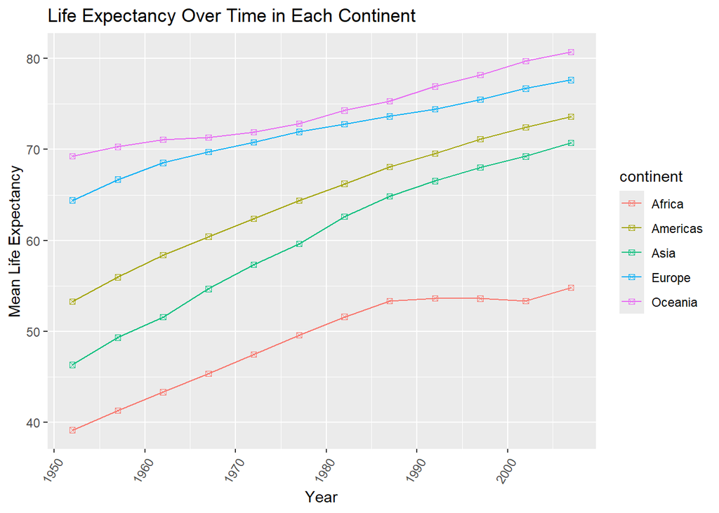

```r
gapminder %>%
  group_by(continent, year) %>%
  summarize(ave_lifex=mean(lifeExp), .groups = "keep") %>%
  ggplot(aes(x=year, y=ave_lifex, group = continent, color= continent))+
  geom_line()+
  geom_point(shape=7)+
  labs(title = "Life Expectancy Over Time in Each Continent",
       x="Year",
       y="Mean Life Expectancy")+
  theme(axis.text.x = element_text(angle = 60, hjust = 1))
```

*The life expectancy in Africa between 1987 and 2002 barely changed, and I think this is because of the disease outbreak like AIDS, which increases its mortality rate. So, despite having a high birth rate, the high mortality rate keeps the life expectancy rate constant*

```r
gapminder %>%
  filter(continent=="Africa" & year>=1987 & year <= 2002) %>%
  group_by(year) %>%
  summarize(ave_life=mean(lifeExp))
```

```
## # A tibble: 4 × 2
##    year ave_life
##   <int>    <dbl>
## 1  1987     53.3
## 2  1992     53.6
## 3  1997     53.6
## 4  2002     53.3
```

7. We are interested in the relationship between per capita GDP and life expectancy; i.e. does having more money help you live longer? Show this as a plot.